# Add phases after EPMA analysis

YASUMOTO Atsushi

2019-01-04

# Intro

This vignette introduce a way to quantify X-ray map even if, in accident, there are some phases without spot analysis. For accurate analysis, I highly recommend careful observation prior to EPMA analysis, so that as less phases as possible being missed.

Please read “Basic usage” before hand.

# Preparation

This section prepares package, files, and modify sample data. An original sample dataset is same as that used in “Basic usage”. However, the dataset will be modified to let a phase be not analyzed by EPMA spot analysis. This is why “Specify directories containing data” and “Load Data” belongs to “Preparation” despite they belongs to Analysis section of “Basic usage”.

## Load package

```r
library(qntmap)
```

## Move to working directory

```r
wd <- tempdir() # Arbitrary
setwd(wd)
```

## Copy example data

or any original data.

```r
file.copy(
  from = system.file('extdata', 'minimal', package = 'qntmap'),
  to = wd,
  recursive = TRUE
)
```

```
#> [1] TRUE
```

`TRUE` indicates files are successfully copied. Check if really files are copied by `dir()`.

```r
dir(file.path(wd, 'minimal'), recursive = TRUE, all.files = TRUE)
```

```
#>  [1] ".map/1/0.cnd"            ".map/1/1.cnd"
#>  [3] ".map/1/1_map.txt"        ".map/1/2.cnd"
#>  [5] ".map/1/2_map.txt"        ".qnt/.cnd/elemw.cnd"
#>  [7] ".qnt/bgm.qnt"            ".qnt/bgp.qnt"
#>  [9] ".qnt/elem.qnt"           ".qnt/elint.qnt"
#> [11] ".qnt/mes.qnt"            ".qnt/net.qnt"
#> [13] ".qnt/pkint.qnt"          ".qnt/stg.qnt"
#> [15] ".qnt/wt.qnt"             ".~lock.params_xmap.csv#"
#> [17] "README.md"               "params_qnt.csv"
#> [19] "params_xmap.csv"
```

## Specify directories containing data

```r
dir_map <- 'minimal/.map/1'
dir_qnt <- 'minimal/.qnt'
```

## Load data

```r
xmap <- read_xmap(dir_map)
qnt <- read_qnt(dir_qnt)
```

## Check quantified data

In the original dataet, 20 spots are analyzed by EPMA on both olivine and quartz.

```r
table(qnt$cnd$phase)
```

```
#>
#>  Ol Qtz
#>  20  20
```

## Modify data

Let’s delete quartz from dataset and reload.

After `read_qnt()` is performed, a file `phase_list0.csv` is created under `dir_qnt`. This file consists of 3 columns `id`, `phase`, and `use`.

**Do not** edit `id`.

**Correct** `phase` in the analyzed phases are not expected ones, or in case some phase needs be sub-grouped due to large compositional variation. For example, substitute Ol by Ol_Fe and Ol_Mg based on Fe/Mg ratio.

**Correct** `use` in case there are bad results.

This time, let `use` be `FALSE` if `phase` is Qtz, and retry `read_qnt`

To do it on R, execute codes below. Be sure to specify a path to modified csv file to `phase_list` parameter of `read_qnt`. Also, `renew` parameter of `read_qnt` must be `TRUE`.

```r
phase_list <- read.csv('phase_list0.csv')
phase_list$use[phase_list$phase == 'Qtz'] <- FALSE
write.csv(phase_list, file.path(dir_qnt, 'phase_list_no_qtz.csv'))
qnt <- read_qnt(dir_qnt, phase_list = file.path(dir_qnt, 'phase_list_no_qtz.csv'), renew = TRUE)
```

After editing, only olivine is said to be quantified.

```r
table(qnt$cnd$phase)
```

```
#>
#> Ol
#> 20
```

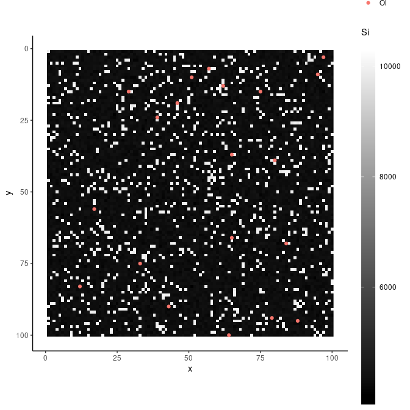

# Analysis

## Cluster analysis

### Initialize cluster centers

```r
centers <- find_centers(xmap, qnt)
centers
```

```
#> # A tibble: 1 x 3
#>   phase    Si    Mg
#>   <chr> <dbl> <dbl>
#> 1 Ol    4246. 5726.
```

### Compare the initial centroids with X-ray map plotted with heatmap

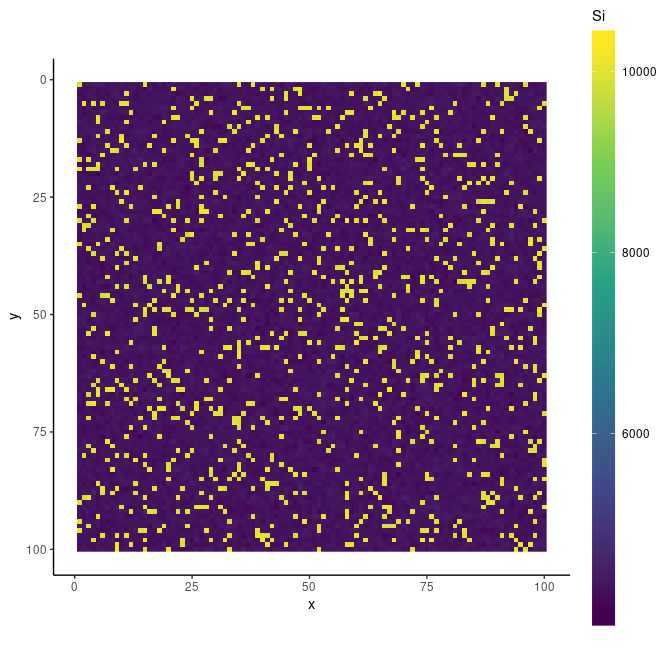

```r
plot(xmap, 'Si', interactive = FALSE)
```

In this case, an analysist will notice there is something other than olivine. Let’s mouse over the **interactive map** and one will see one of the coordinates of quartz (e.g., x = 18, y = 28). Keep it in your note.

### Add initial centers

#### on R

Add initial centers by using `add_centers`.

```r
centers <- add_centers(centers = centers, xmap = xmap, x = 18, y = 28, p = 'Qtz')
```

Then, Qtz is properly added to `centers`.

```r
print(centers)
```

```
#> # A tibble: 2 x 3
#>   phase     Si    Mg
#> * <chr>  <dbl> <dbl>
#> 1 Ol     4246. 5726.
#> 2 Qtz   10126     0
```

#### on Spreadsheet program + R

- Open `centers_initial0.csv` in the current directory (try `getwd()` on R if unknown).
- Edit it
- Save it
- Reload on R by `centers <- read.csv('path to an updated csv file')`

### Cluster and quantify

As Qtz is not quantified during spot analysis, calibration curves for Qtz is substituted by results of regression analysis without considering different phases. Try “Quasi-calibrations” in case phases not quantified have known and constant chemical compositions.

```r
cluster <- cluster_xmap(xmap, centers)
qmap <- quantify(xmap, qnt, cluster)
```

```r
summary(cluster)
```

```
#> [1] 0.90005667 0.09994333
```

```r
summary(qmap)
```

```
#>   Element  Min. 1st Qu. Median   Mean 3rd Qu.   Max.
#> 1      Si 40.54   42.49  42.97  48.69   43.52 103.91
#> 2      Mg  0.00   56.46  57.10  51.49   57.68  59.87
#> 3   Total 96.43   99.46 100.18 100.18  100.88 104.37
#>
#> Note that Total is not sum each column
```

#### Quasi-calibrations

In case phases without spot analysis have known chemical compositions, their calibration curves can be calculated by specifying their chemical compositions in csv format.

For example, prepare a csv file, and specify it to `fix` parameter of `quantify()`.

```r
csv <- paste(
    'phase, element, wt',
    'Qtz,   Si,      100',
    sep = "\n"
  )
cat(csv)
```

```
#> phase, element, wt
#> Qtz,   Si,      100
```

```r
qmap2 <- quantify(xmap, qnt, cluster, fix = csv)
summary(qmap2)
```

```
#>   Element  Min. 1st Qu. Median   Mean 3rd Qu.   Max.
#> 1      Si 40.54   42.49  42.97  48.54   43.52 102.41
#> 2      Mg  0.00   56.46  57.10  51.49   57.68  59.87
#> 3   Total 96.43   99.34 100.04 100.03  100.73 104.37
#>
#> Note that Total is not sum each column
```

Of course, `csv` parameter can be a path to a csv file, unlike the above example, which gave csv data the `csv` parameter.